# Python標準モジュールのhttp.serverを使ったWebサーバーの起動とWebアプリケーション

> オブジェクト指向プログラミングおよび演習2

> Pythonの標準モジュールのhttp.serverを利用して、簡易Webサーバーを起動してみましょう。

## Webサーバー用ディレクトリの作成とWebページの追加

まずはWebサーバー用のディレクトリを作成します。ディレクトリ名は便宜上`oop2web`としましたが、任意に変更して良いです。  
（※この作業は、最初の一度のみ行ってください。）

```bash
$ mkdir oop2web
$ cd oop2web
```

Finderでディレクトリを開き、そのディレクトリ内に、`index.html`のファイル名で適当なWebページを作成します。 次のコマンドは、カレントディレクトリをFinderで開くことができます。

```bash
$ open .
```

## PythonのWebサーバーモジュールを呼び出し

```bash
$ python -m http.server 8080
```

または

```bash
$ python3 -m http.server 8080
```

`-m`オプションは、pythonのモジュール呼び出しのためのオプションです。これを使用すると、わざわざモジュールを起動するためのPythonスクリプトを書かずにコマンドライン上で実行が可能です。

### 動作確認

Webブラウザにて、http://localhost:8080/ にアクセスし、作成した`index.html`の内容が表示されればOK。

ポート番号として、`8080`を指定しましたが、他のアプリケーションによって使用中の場合は、他のポート番号に切り替えてください。

### サーバーの停止

ターミナルで`[control] + [c]`で強制的にプログラムを停止できます。

一度で終了できない場合は、何度もキー入力してください。

# CGIを使用したWebアプリケーション

## HTTPを利用したアプリケーション

通常のHTTPによるリクエストの処理は、以下の図で表せます。

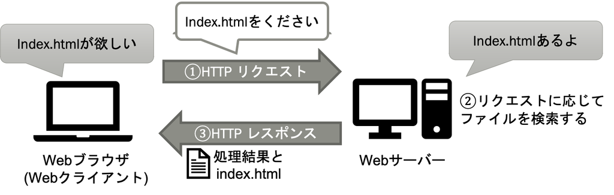

それに対して、Webアプリケーションは、HTTPのリクエストに応じた処理をWebサーバー側にて行い、リクエストの内容やパラメータに応じたコンテンツをレスポンスとして生成し、返します。

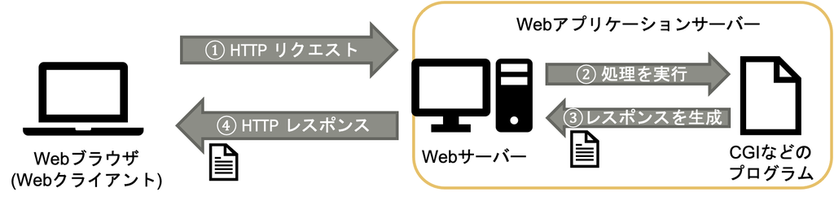

今回作成するWebアプリケーションサーバーは、通常のWebサーバーの機能を制限し、すべてのリクエストに対してPythonのプログラムによる操作を行ってレスポンスデータを生成します。 それに対して、WebサーバーはWebサーバーとして利用し、特定のパスへのリクエストのみをPython、Perl、Rubyなどのスクリプトに渡すWebサーバー主体のプログラムもあります。そういった仕組みのことをCGI(Common Gateway Interface)と呼びますが、この講義では使用しません。

#### (参考)Python CGI

講義では使用しませんが、以下のリンク先を参照していただければと思います。

- [cgi --- CGI (ゲートウェイインタフェース規格) のサポート — Python 3.8.6 ドキュメント](https://docs.python.org/ja/3.8/library/cgi.html)

また、http.serverをCGIモードで起動するには、以下のコマンドを使用します。

```bash
$ python3 -m http.server 8080 --cgi
```

PythonのCGIスクリプトのサンプルは以下のようになります。

```python
#!/usr/bin/env python
# coding:utf-8

import cgi
import cgitb
cgitb.enable()

print("Content-Type: text/html; charset=utf-8\n\n")
print("<html><h1>Hello, Python CGI!!</h1>")

form = cgi.FieldStorage() # リクエストパラメータの取得

print("<ol>")

for key in form:
    value = form[key].value
    print('<li>%s: %s</li>' % (key, value))

print("</ol>")
print("</html>")
```

このスクリプトを、`$ python3 -m http.server 8080 --cgi`のコマンドを実行したディレクトリ以下に、`cgi-bin`ディレクトリを作成し、例えば`test_cgi.py`という名前で`cgi-bin`ディレクトリ以下に保存してください。

その状態で、ブラウザを開き、`http://localhost:8080/cgi-bin/test_cgi.py?hoge=HOGE`へアクセスしてみてください。

以下の様にGETパラメータが解析されて表示されていれば成功です。

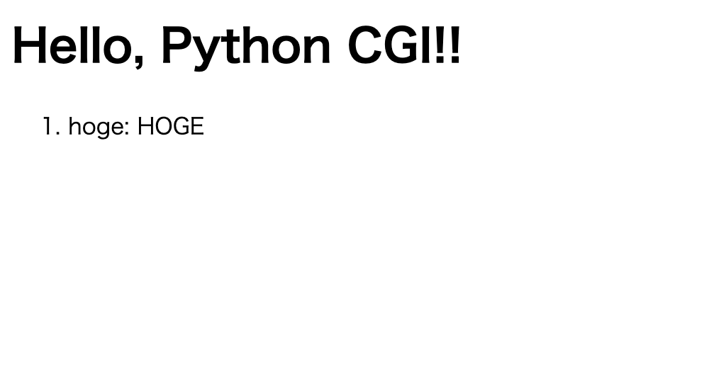